# Multi-Level Linguistic Alignment in a Dynamic CPS Tasks: Step 3 Model 1

Nick Duran

10/14/21

## Notebook contains code for replicating section in manuscript: Analysis 1: Alignment over time

#### Step 1: Import main data file and run script to prep variables for analysis

```r
library(tidyverse)
library(pander)
```

```r
main.data = read.csv("Step1_PrepareFeatures.csv")

source("Step3_helper.R")
main.data.20 = variable_prep(main.data)

pander(names(main.data.20))
```

*Team*, *School*, *Block*, *Concept*, *Goal*, *Level*, *trophy*, *level_duration*, *relative_start_time*, *revisited*, *speaker_target*, *aligner_score*, *aligner_role*, *utterlen_target*, *utterlen_aligner*, *semantic*, *lexical*, *syn2nd*, *syn3nd*, *syntax*, *ordering_prop*, *level_durationZ*, *utterlen_targetZ*, *utterlen_alignerZ*, *relative_start_timeZ*, *Block.l*, *subject_id* and *team_id*

```r
# head(main.data.20)
```

- Relies heavily on “Step3_helper.R.” This code does the following:
  - remove levels that are fewer than 20 turns
  - Convert # of turns to a running proportion score
  - Get z-scores for relevant variables
  - create ordered factor for block (interested in linear trend)
  - create random factor for within subject variance (making sure each unique subject is signified given their school and team)

#### Step 2: Check the distributions of the main outcome linguistic variables

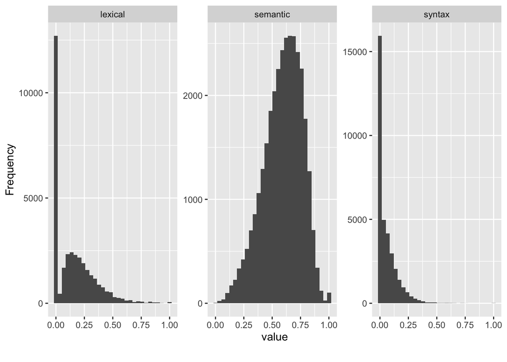

```r
library(DataExplorer)

g1 = main.data.20 %>% select(lexical, semantic, syntax)
plot_histogram(g1)
```

The outcome variables of lexical and syntactic is clearly distribute with clumping at zero (hurdle, bounded) with a skew in the positive values (unbounded, gamma), As such, what is required is the use of zero-inflated gamma models, i.e., gamma hurdle models; zero-altered gamma models; two-part models (a binomial model for predicting occurrence of nonzero, a second [linear model (or Gamma, or truncated Normal, or log-Normal)] for evaluating the relationship of nonzero value to predictors)

#### Step 3: Build zero-inflated gamma models: LEXICAL

```r
library(glmmTMB)
library(parameters)
```

How to interpret (generally):

For the **linear component (gamma)**, we use a log link that allows us to predict the model-adjusted mean of the non-zero data on the log scale. Being on the log scale, we can also exponentiate to make claims about how a unit increase in response value x leads to a probabilistic decrease or increase in the mean of the outcome. For example: A 1 unit increase in x leads to a 0.012 decrease in the mean of the outcome. Put another way, increasing x by 1 causes a 98.8% reduction in the predictor.

For the **binomial component** we use a logit link to predict “0” (nonoccurrence) and then exponentiate the resulting coefficient to report the probability of seeing a nonoccurrence.

```r
zigamma_lex <- glmmTMB(lexical ~ ordering_prop + Block.l + aligner_role + relative_start_timeZ + level_durationZ + utterlen_alignerZ + Concept + (1|subject_id),
                         family = ziGamma(link = "log"),
                         ziformula = ~ ordering_prop + Block.l + aligner_role + relative_start_timeZ + level_durationZ + utterlen_alignerZ + Concept + (1|subject_id),
                         data = main.data.20)
pander(summary(zigamma_lex))
```

- **logLik**:
  - *-7920*
- **family**: Gamma
- **link**: log
- **ngrps**:
  - **cond**:

    | subject_id |
    | --- |
    | 280 |

  - **zi**:

    | subject_id |
    | --- |
    | 280 |

- **nobs**: *34294*
- **coefficients**:
  - **cond**:

    |  | Estimate | Std. Error | z value | Pr(>\|z\|) |
    | --- | --- | --- | --- | --- |
    | **(Intercept)** | -1.354 | 0.01032 | -131.2 | 0 |
    | **ordering_prop** | -0.02977 | 0.01402 | -2.124 | 0.03367 |
    | **Block.l.L** | -0.0006187 | 0.007776 | -0.07956 | 0.9366 |
    | **Block.l.Q** | -0.00653 | 0.007283 | -0.8965 | 0.37 |
    | **aligner_rolecontroller** | -0.04051 | 0.008612 | -4.704 | 2.552e-06 |
    | **relative_start_timeZ** | 0.009666 | 0.00479 | 2.018 | 0.0436 |
    | **level_durationZ** | -0.003378 | 0.005317 | -0.6353 | 0.5252 |
    | **utterlen_alignerZ** | -0.03687 | 0.003227 | -11.43 | 3.134e-30 |
    | **ConceptPoT** | -0.01102 | 0.00975 | -1.131 | 0.2582 |

  - **zi**:

    |  | Estimate | Std. Error | z value | Pr(>\|z\|) |
    | --- | --- | --- | --- | --- |
    | **(Intercept)** | -0.6364 | 0.02869 | -22.18 | 5.208e-109 |
    | **ordering_prop** | 0.029 | 0.03955 | 0.7333 | 0.4634 |
    | **Block.l.L** | 0.06869 | 0.02221 | 3.093 | 0.001982 |
    | **Block.l.Q** | -0.02733 | 0.02073 | -1.319 | 0.1873 |
    | **aligner_rolecontroller** | -0.1013 | 0.02439 | -4.154 | 3.264e-05 |
    | **relative_start_timeZ** | -0.02474 | 0.01351 | -1.831 | 0.06714 |
    | **level_durationZ** | -0.05285 | 0.01484 | -3.561 | 0.0003699 |
    | **utterlen_alignerZ** | -0.9178 | 0.0205 | -44.77 | 0 |
    | **ConceptPoT** | -0.0006667 | 0.02746 | -0.02428 | 0.9806 |

  - **disp**:
- **sigma**: *0.5999*
- **vcov**:

- **varcor**:
  - **cond**:
    - **subject_id**:

      |  | (Intercept) |
      | --- | --- |
      | **(Intercept)** | 0.004329 |

  - **zi**:
    - **subject_id**:

      |  | (Intercept) |
      | --- | --- |
      | **(Intercept)** | 0.02199 |

- **AICtab**:

  | AIC | BIC | logLik | deviance | df.resid |
  | --- | --- | --- | --- | --- |
  | 15882 | 16059 | -7920 | 15840 | 34273 |

- **call**: `glmmTMB(formula = lexical ~ ordering_prop + Block.l + aligner_role + relative_start_timeZ + level_durationZ + utterlen_alignerZ + Concept + (1 | subject_id), data = main.data.20, family = ziGamma(link = "log"), ziformula = ~ordering_prop + Block.l + aligner_role + relative_start_timeZ + level_durationZ + utterlen_alignerZ + Concept + (1 | subject_id), dispformula = ~1)`

Let’s do the exponentiation of the coefficients for clearer interpretation

```r
pander(model_parameters(zigamma_lex, exponentiate = T))
```

[output not shown]

Show the model parameters in a cleaner format

```r
library(strengejacke)
tab_model(zigamma_lex,
          show.intercept = FALSE,
          show.r2 = TRUE,
          show.icc = FALSE,
          show.re.var = FALSE,
          show.ngroups = FALSE,
          show.obs = FALSE,
          string.pred = "Incidence Rate Ratios"
          )
```

```
## Argument 'df_method' is deprecated. Please use 'ci_method' instead.
```

|  | lexical |  |  |  |
| --- | --- | --- | --- | --- |
| Incidence Rate Ratios | Estimates | CI | p |  |
| Count Model |  |  |  |  |
| ordering prop | 0.97 | 0.94 – 1.00 | **0.034** |  |
| Block l [linear] | 1.00 | 0.98 – 1.01 | 0.937 |  |
| Block l [quadratic] | 0.99 | 0.98 – 1.01 | 0.370 |  |
| aligner role [controller] | 0.96 | 0.94 – 0.98 | **<0.001** |  |
| relative start timeZ | 1.01 | 1.00 – 1.02 | **0.044** |  |
| level durationZ | 1.00 | 0.99 – 1.01 | 0.525 |  |
| utterlen alignerZ | 0.96 | 0.96 – 0.97 | **<0.001** |  |
| Concept [PoT] | 0.99 | 0.97 – 1.01 | 0.258 |  |
| Zero-Inflated Model |  |  |  |  |
| ordering prop | 1.03 | 0.95 – 1.11 | 0.463 |  |
| Block l [linear] | 1.07 | 1.03 – 1.12 | **0.002** |  |
| Block l [quadratic] | 0.97 | 0.93 – 1.01 | 0.187 |  |
| aligner role [controller] | 0.90 | 0.86 – 0.95 | **<0.001** |  |
| relative start timeZ | 0.98 | 0.95 – 1.00 | 0.067 |  |
| level durationZ | 0.95 | 0.92 – 0.98 | **<0.001** |  |
| utterlen alignerZ | 0.40 | 0.38 – 0.42 | **<0.001** |  |
| Concept [PoT] | 1.00 | 0.95 – 1.05 | 0.981 |  |
| Marginal R<sup>2</sup> / Conditional R<sup>2</sup> | 0.005 / 0.017 |  |  |  |

How to interpret (specifically):

For the **linear component (gamma)** component, assuming a non-zero value, a 1 unit increase in ordering_prop (from the start [0] to the end [1]) leads to a 0.97 decrease in the mean of lexical. Put in another way, increasing ordering_prop 0 to 1 (start to finish) causes a 2.93% (1-(exp(-0.0297724))) * 100 reduction in the mean amount of lexical alignment. Or, we can change the unit size to .10 increments. If so, increasing ordering_prop by 1/10 increments causes a 0.30% (1-exp(-0.0297724 * 0.1)) * 100 reduction in the mean amount of lexical.

For the **binomial component** predicting whether lexical alignment occurred at all, although no change of likelihood across a level, for likelihood across blocks, the odds of there being no lexical alignment increased by 1.07 times exp(0.0686873). That is, there was an 7.11% increase in having no occurrence of lexical alignment by the final round.

#### Step 4: Build zero-inflated gamma models: SYNTACTIC (without lexical boost)

```r
zigamma_syn <- glmmTMB(syntax ~ ordering_prop + Block.l + aligner_role + relative_start_timeZ + level_durationZ + utterlen_alignerZ + Concept + (1|subject_id),
                         family = ziGamma(link = "log"),
                         ziformula = ~ ordering_prop + Block.l + aligner_role + relative_start_timeZ + level_durationZ + utterlen_alignerZ + Concept + (1|subject_id),
                         data = main.data.20)

pander(summary(zigamma_syn))
```

- **logLik**:
  - *4058*
- **family**: Gamma
- **link**: log
- **ngrps**:
  - **cond**:

    | subject_id |
    | --- |
    | 280 |

  - **zi**:

    | subject_id |
    | --- |
    | 280 |

- **nobs**: *34294*
- **coefficients**:
  - **cond**:

    |  | Estimate | Std. Error | z value | Pr(>\|z\|) |
    | --- | --- | --- | --- | --- |
    | **(Intercept)** | -2.184 | 0.01314 | -166.3 | 0 |
    | **ordering_prop** | -0.07818 | 0.01896 | -4.124 | 3.719e-05 |
    | **Block.l.L** | -0.01409 | 0.01035 | -1.361 | 0.1734 |
    | **Block.l.Q** | -0.01238 | 0.009689 | -1.278 | 0.2013 |
    | **aligner_rolecontroller** | -0.0464 | 0.0115 | -4.036 | 5.446e-05 |
    | **relative_start_timeZ** | 0.01015 | 0.00642 | 1.582 | 0.1137 |
    | **level_durationZ** | 0.02345 | 0.006813 | 3.442 | 0.0005784 |
    | **utterlen_alignerZ** | 0.02907 | 0.004765 | 6.1 | 1.063e-09 |
    | **ConceptPoT** | 0.008847 | 0.01297 | 0.6823 | 0.495 |

  - **zi**:

    |  | Estimate | Std. Error | z value | Pr(>\|z\|) |
    | --- | --- | --- | --- | --- |
    | **(Intercept)** | -0.3624 | 0.02931 | -12.36 | 4.11e-35 |
    | **ordering_prop** | 0.0427 | 0.0396 | 1.078 | 0.2808 |
    | **Block.l.L** | 0.05512 | 0.02228 | 2.474 | 0.01335 |
    | **Block.l.Q** | -0.0105 | 0.02081 | -0.5045 | 0.6139 |
    | **aligner_rolecontroller** | -0.1978 | 0.02448 | -8.079 | 6.53e-16 |
    | **relative_start_timeZ** | -0.01444 | 0.01356 | -1.065 | 0.287 |
    | **level_durationZ** | -0.04461 | 0.01506 | -2.962 | 0.00306 |
    | **utterlen_alignerZ** | -1.205 | 0.02174 | -55.44 | 0 |
    | **ConceptPoT** | 0.007958 | 0.0276 | 0.2883 | 0.7731 |

  - **disp**:
- **sigma**: *0.7613*
- **vcov**:

- **varcor**:
  - **cond**:
    - **subject_id**:

      |  | (Intercept) |
      | --- | --- |
      | **(Intercept)** | 0.00235 |

  - **zi**:
    - **subject_id**:

      |  | (Intercept) |
      | --- | --- |
      | **(Intercept)** | 0.03005 |

- **AICtab**:

  | AIC | BIC | logLik | deviance | df.resid |
  | --- | --- | --- | --- | --- |
  | -8074 | -7897 | 4058 | -8116 | 34273 |

- **call**: `glmmTMB(formula = syntax ~ ordering_prop + Block.l + aligner_role + relative_start_timeZ + level_durationZ + utterlen_alignerZ + Concept + (1 | subject_id), data = main.data.20, family = ziGamma(link = "log"), ziformula = ~ordering_prop + Block.l + aligner_role + relative_start_timeZ + level_durationZ + utterlen_alignerZ + Concept + (1 | subject_id), dispformula = ~1)`

```r
pander(model_parameters(zigamma_syn, exponentiate = T))
```

[output not shown]

```r
tab_model(zigamma_syn,
          show.intercept = FALSE,
          show.r2 = TRUE,
          show.icc = FALSE,
          show.re.var = FALSE,
          show.ngroups = FALSE,
          show.obs = FALSE
          )
```

```
## Argument 'df_method' is deprecated. Please use 'ci_method' instead.
```

|  | syntax |  |  |  |
| --- | --- | --- | --- | --- |
| Predictors | Estimates | CI | p |  |
| Count Model |  |  |  |  |
| ordering prop | 0.92 | 0.89 – 0.96 | **<0.001** |  |
| Block l [linear] | 0.99 | 0.97 – 1.01 | 0.173 |  |
| Block l [quadratic] | 0.99 | 0.97 – 1.01 | 0.201 |  |
| aligner role [controller] | 0.95 | 0.93 – 0.98 | **<0.001** |  |
| relative start timeZ | 1.01 | 1.00 – 1.02 | 0.114 |  |
| level durationZ | 1.02 | 1.01 – 1.04 | **0.001** |  |
| utterlen alignerZ | 1.03 | 1.02 – 1.04 | **<0.001** |  |
| Concept [PoT] | 1.01 | 0.98 – 1.03 | 0.495 |  |
| Zero-Inflated Model |  |  |  |  |
| ordering prop | 1.04 | 0.97 – 1.13 | 0.281 |  |
| Block l [linear] | 1.06 | 1.01 – 1.10 | **0.013** |  |
| Block l [quadratic] | 0.99 | 0.95 – 1.03 | 0.614 |  |
| aligner role [controller] | 0.82 | 0.78 – 0.86 | **<0.001** |  |
| relative start timeZ | 0.99 | 0.96 – 1.01 | 0.287 |  |
| level durationZ | 0.96 | 0.93 – 0.99 | **0.003** |  |
| utterlen alignerZ | 0.30 | 0.29 – 0.31 | **<0.001** |  |
| Concept [PoT] | 1.01 | 0.95 – 1.06 | 0.773 |  |
| Marginal R<sup>2</sup> / Conditional R<sup>2</sup> | 0.005 / 0.009 |  |  |  |

For the **linear component (gamma)** component, assuming a non-zero value, a 1 unit increase in ordering_prop (from the start [0] to the end [1]) leads to a 0.92 decrease in the mean of syntax. Put in another way, increasing ordering_prop 0 to 1 (start to finish) causes a 7.52% (1-(exp(-0.078183))) * 100 reduction in the mean amount of syntactic alignment. Or, we can change the unit size to .10 increments. If so, increasing ordering_prop by 1/10 increments causes a 0.78% (1-exp(-0.078183 * 0.1)) * 100 reduction in the mean amount of syntax.

For the **binomial component** predicting whether syntactic alignment occurred at all, although no change of likelihood across a level, for likelihood across blocks, the odds of there being no syntactic alignment increased by 1.06 times exp(0.055121). That is, there was an 5.67% increase in having no occurrence of syntactic alignment by the final round.

#### Step 5: Table to be used for paper

```r
tab_model(zigamma_lex, zigamma_syn,
          show.ci = 0.95,
          rm.terms = c("Block.l.Q"),
          show.intercept = FALSE,
          pred.labels = c("ordering_prop"="Utterance order", "Block.l.L"="Block (linear trend)", "BlockExpBlock2"="Block 2 (vs Warmup)", "aligner_rolecontroller"="Role [controller]", "relative_start_timeZ"="Level start time", "level_durationZ"="Level duration", "utterlen_alignerZ"="Utterance length", "ConceptPoT" = "Concept [PoT]", "Revisited_birevisit" = "Revisit [yes]", "XQ_know"="Familiarity [yes]", "femdomin"="Majority Female [yes]"),
          # title = "",
          digits = 3,
          digits.re = 3,
          dv.labels = c("Lexical", "Syntactic"),
          show.r2 = FALSE,
          show.icc = FALSE,
          show.re.var = FALSE,
          show.ngroups = FALSE,
          show.obs = FALSE,
          use.viewer = TRUE)
```

```
## Argument 'df_method' is deprecated. Please use 'ci_method' instead.
## Argument 'df_method' is deprecated. Please use 'ci_method' instead.
```

|  | Lexical |  |  | Syntactic |  |  |
| --- | --- | --- | --- | --- | --- | --- |
| Predictors | Estimates | CI | p | Estimates | CI | p |
| Utterance order | 0.971 | 0.944 – 0.998 | **0.034** | 0.925 | 0.891 – 0.960 | **<0.001** |
| Block (linear trend) | 0.999 | 0.984 – 1.015 | 0.937 | 0.986 | 0.966 – 1.006 | 0.173 |
| Role [controller] | 0.960 | 0.944 – 0.977 | **<0.001** | 0.955 | 0.933 – 0.976 | **<0.001** |
| Level start time | 1.010 | 1.000 – 1.019 | **0.044** | 1.010 | 0.998 – 1.023 | 0.114 |
| Level duration | 0.997 | 0.986 – 1.007 | 0.525 | 1.024 | 1.010 – 1.037 | **0.001** |
| Utterance length | 0.964 | 0.958 – 0.970 | **<0.001** | 1.029 | 1.020 – 1.039 | **<0.001** |
| Concept [PoT] | 0.989 | 0.970 – 1.008 | 0.258 | 1.009 | 0.984 – 1.035 | 0.495 |
| Zero-Inflated Model |  |  |  |  |  |  |
| Utterance order | 1.029 | 0.953 – 1.112 | 0.463 | 1.044 | 0.966 – 1.128 | 0.281 |
| Block (linear trend) | 1.071 | 1.025 – 1.119 | **0.002** | 1.057 | 1.012 – 1.104 | **0.013** |
| Role [controller] | 0.904 | 0.861 – 0.948 | **<0.001** | 0.821 | 0.782 – 0.861 | **<0.001** |
| Level start time | 0.976 | 0.950 – 1.002 | 0.067 | 0.986 | 0.960 – 1.012 | 0.287 |
| Level duration | 0.949 | 0.921 – 0.977 | **<0.001** | 0.956 | 0.929 – 0.985 | **0.003** |
| Utterance length | 0.399 | 0.384 – 0.416 | **<0.001** | 0.300 | 0.287 – 0.313 | **<0.001** |
| Concept [PoT] | 0.999 | 0.947 – 1.055 | 0.981 | 1.008 | 0.955 – 1.064 | 0.773 |

#### Step 6: Build mixed effect models: SEMANTIC

Semantic

```r
library(lme4)

## observations: 1709 rows were not computed because one of the utterances contained words not in the semantic space
## looks normally distributed, slightly skewed to the right
# g1 = gather(df.sl3, "lexical", "semantic", "syn2nd", key="ling_align", value="values")
# p1 = ggplot(g1, aes(values))
# p1 +  geom_histogram(data=subset(g1,ling_align == 'semantic'), binwidth = 0.05)

lmer_sem = lmer(semantic ~ ordering_prop + Block.l + aligner_role + relative_start_timeZ + level_durationZ + utterlen_alignerZ + Concept + (1|subject_id), main.data.20);

pander(summary(lmer_sem))
```

[output not shown]

```r
tab_model(lmer_sem)
```

```
## Argument 'df_method' is deprecated. Please use 'ci_method' instead.
```

|  | semantic |  |  |
| --- | --- | --- | --- |
| Predictors | Estimates | CI | p |
| (Intercept) | 0.58 | 0.58 – 0.59 | **<0.001** |
| ordering prop | 0.01 | 0.00 – 0.02 | **0.003** |
| Block l [linear] | 0.00 | -0.00 – 0.00 | 0.900 |
| Block l [quadratic] | -0.00 | -0.01 – 0.00 | 0.152 |
| aligner role [controller] | 0.01 | 0.01 – 0.02 | **<0.001** |
| relative start timeZ | 0.00 | -0.00 – 0.00 | 0.759 |
| level durationZ | 0.00 | -0.00 – 0.00 | 0.092 |
| utterlen alignerZ | 0.05 | 0.05 – 0.05 | **<0.001** |
| Concept [PoT] | 0.00 | -0.00 – 0.01 | 0.667 |
| Random Effects |  |  |  |
| σ<sup>2</sup> | 0.03 |  |  |
| τ<sub>00</sub> <sub>subject_id</sub> | 0.00 |  |  |
| ICC | 0.01 |  |  |
| N <sub>subject_id</sub> | 280 |  |  |
| Observations | 32581 |  |  |
| Marginal R<sup>2</sup> / Conditional R<sup>2</sup> | 0.080 / 0.089 |  |  |

#### Step 7: Table to be used for paper

```r
tab_model(lmer_sem,
          show.ci = 0.95, #FALSE
          rm.terms = c("Block.l.Q"),
          show.intercept = FALSE,
          pred.labels = c("ordering_prop"="Utterance order", "Block.l.L"="Block (linear trend)", "BlockExpBlock2"="Block 2 (vs Warmup)", "aligner_rolecontroller"="Role [controller]", "relative_start_timeZ"="Level start time", "level_durationZ"="Level duration", "utterlen_alignerZ"="Utterance length", "ConceptPoT" = "Concept [PoT]", "Revisited_birevisit" = "Revisit [yes]", "XQ_know"="Familiarity [yes]", "femdomin"="Majority Female [yes]"),
          # title = "",
          digits = 3,
          digits.re = 3,
          dv.labels = c("Semantic"),
          show.re.var = FALSE,
          show.r2 = FALSE,
          show.icc = FALSE,
          show.ngroups = FALSE,
          show.obs = FALSE,
          use.viewer = TRUE)
```

```
## Argument 'df_method' is deprecated. Please use 'ci_method' instead.
```

|  | Semantic |  |  |
| --- | --- | --- | --- |
| Predictors | Estimates | CI | p |
| Utterance order | 0.009 | 0.003 – 0.015 | **0.003** |
| Block (linear trend) | 0.000 | -0.003 – 0.004 | 0.900 |
| Role [controller] | 0.014 | 0.011 – 0.018 | **<0.001** |
| Level start time | 0.000 | -0.002 – 0.002 | 0.759 |
| Level duration | 0.002 | -0.000 – 0.004 | 0.092 |
| Utterance length | 0.048 | 0.046 – 0.050 | **<0.001** |
| Concept [PoT] | 0.001 | -0.003 – 0.005 | 0.667 |

```r
# mod1 = plot_model(lmer_sem, type = "eff", terms = c("ordering_prop"))
# mod1 + labs(title="Semantic Alignment",
#         x ="Ordering", y = "Cosine")
# save_plot("semantic_time.png")
```